# exercise 4

Louis Meller

```r
suppressPackageStartupMessages({
  library(AnnotationHub)
  library(epiwraps)
  library(rtracklayer)
  library(ggplot2)
  library(GenomicRanges)
  library(ensembldb)
})
```

```bash
./prep.sh
```

```r
files <- list.files(path = "data", full.names = TRUE, pattern = "\\.bed")
names(files) <- gsub("\\.bed", "", basename(files))
peaks <- lapply(files, FUN = rtracklayer::import, format = "narrowPeak")
```

## Question 1: What is the proportion of TSS that overlap H3K27ac, H3K27me3, and the combination of both, in each tissue?

First we download genetic data to obtain tss info.

```r
ah <- AnnotationHub()
```

```r
q <- query(ah, c("Mus Musculus", "EnsDb", "GRCm38"))
mouse_db <- ah[[rev(q$ah_id)[1]]]
```

```
## loading from cache
```

```r
seqlevelsStyle(mouse_db) <- "UCSC"
```

```r
transcripts <- transcripts(mouse_db)
tss <- promoters(transcripts)
```

Using this data, we can now calculate the proportion of overlapping peaks with tss regions.

```r
proportion_overlaps <- function(tss, peaks1, peaks2) {
  overlaps1 <- suppressWarnings(overlapsAny(tss, peaks1))
  overlaps2 <- suppressWarnings(overlapsAny(tss, peaks2))
  overlaps_both <- overlaps1 & overlaps2

  c(
    overlaps_first = mean(overlaps1),
    overlaps_second = mean(overlaps2),
    overlaps_both = mean(overlaps_both)
  )
}
```

```r
heart <- data.frame(
  mark = c("H3K27ac", "H3K27me3", "Both"),
  proportion = proportion_overlaps(tss, peaks$H3K27ac_Heart, peaks$H3K27me3_Heart)
)

mesc <- data.frame(
  mark = c("H3K27ac", "H3K27me3", "Both"),
  proportion = proportion_overlaps(tss, peaks$H3K27ac_mESC, peaks$H3K27me3_mESC)
)

rbind(mESC = mesc, heart = heart)
```

```
##                           mark  proportion
## mESC.overlaps_first    H3K27ac 0.241991187
## mESC.overlaps_second  H3K27me3 0.052639213
## mESC.overlaps_both        Both 0.001733689
## heart.overlaps_first   H3K27ac 0.480432110
## heart.overlaps_second H3K27me3 0.157040434
## heart.overlaps_both       Both 0.098965312
```

In both tissues the tss overlapping proportion of peaks is larger for H3K27ac and smaller for H3K27me3. Interestingly the overlapping proportion is over 2x larger in the heart tissue than in mESC.

## Question 2: What is the relationship between the 3 signals (p300, H3K27ac, and H3K27me3), and is it the same in both tissues?

Here we can use an UpSet plot and region overlaps to show the relationship.

```r
overlaps_and_upset <- function(peaks, print_mat = TRUE) {
  if (print_mat) {
    print(suppressWarnings(regionOverlaps(peaks)))
  }

  suppressWarnings(UpSet(make_comb_mat(regionsToUpset(peaks, nsets = length(peaks)))))
}
```

for mESC:

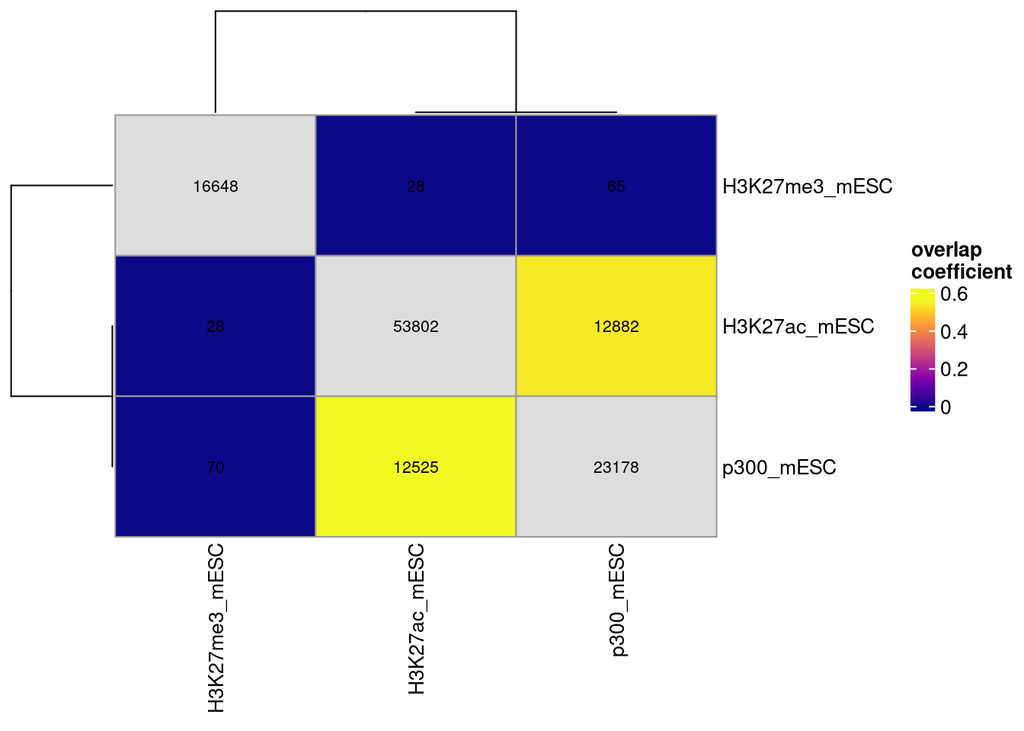

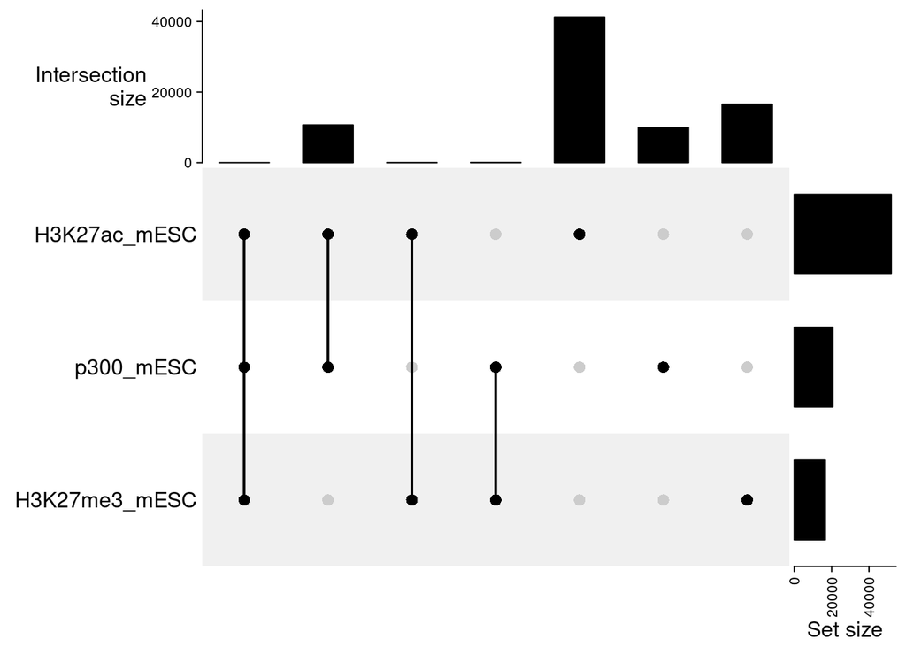

```r
peaks_mESC <- peaks[grepl("mESC", names(peaks))]
overlaps_and_upset(peaks_mESC)
```

and for Heart:

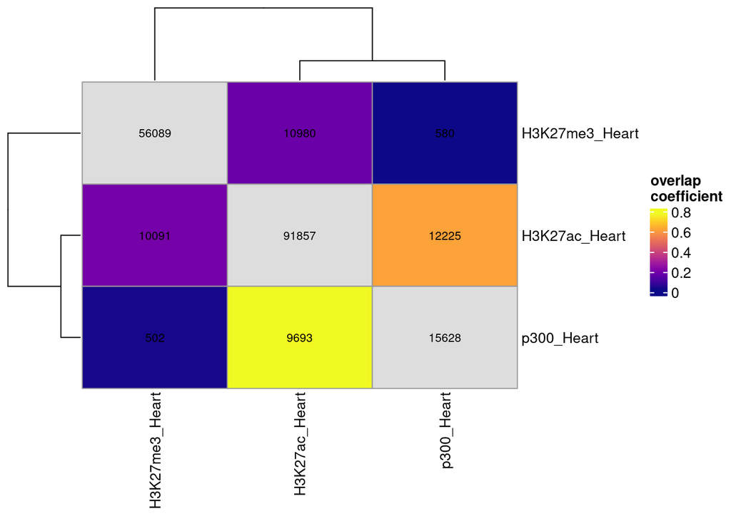

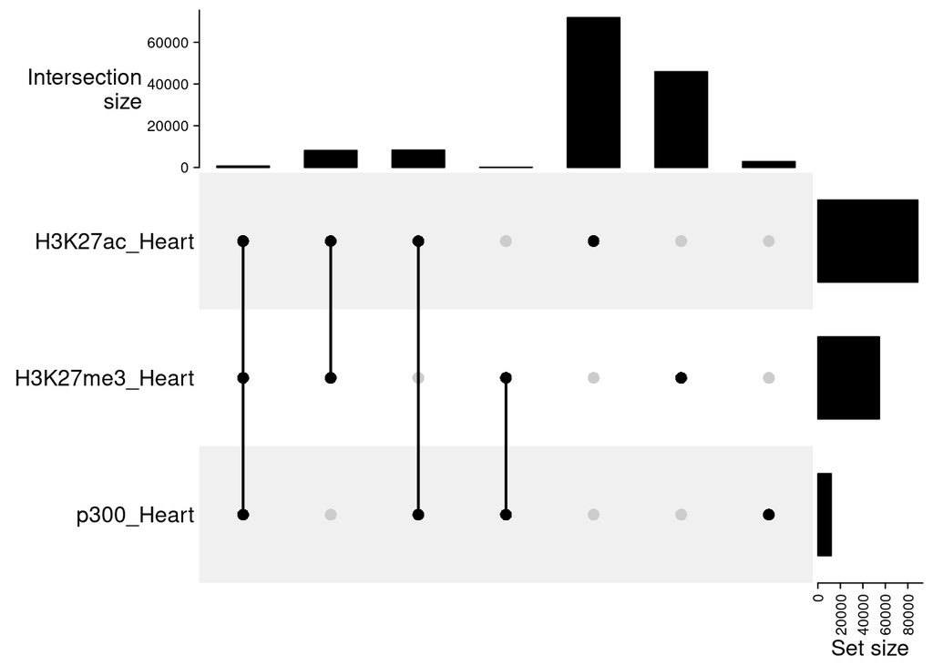

```r
peaks_heart <- peaks[grepl("Heart", names(peaks))]
overlaps_and_upset(peaks_heart)
```

In both tissues, H3K27ac and p300 have many overlaps. In heart tissue H3K27ac and H3K27me3 similarily have many overlaps.

# Question 3: What is the relationship between regulatory elements active in mESC and in the differentiated tissue?

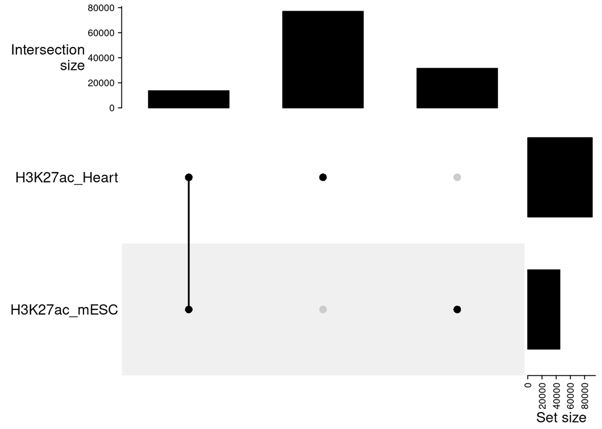

```r
overlaps_and_upset(peaks[grepl("H3K27ac", names(peaks))], FALSE)
```

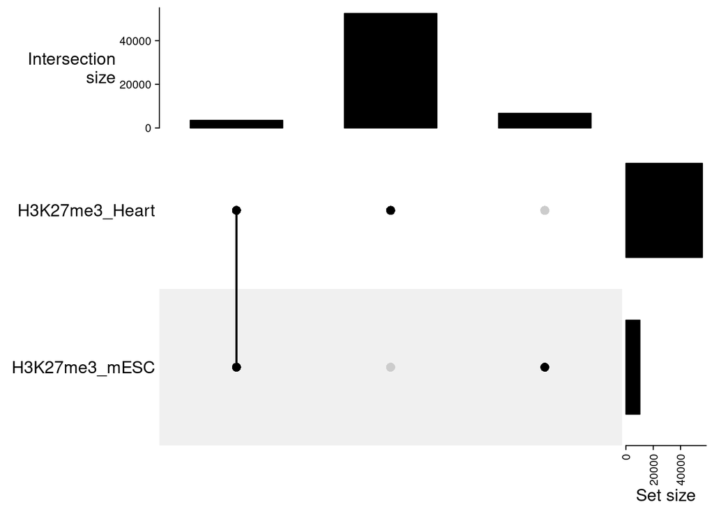

```r
overlaps_and_upset(peaks[grepl("H3K27me3", names(peaks))], FALSE)
```

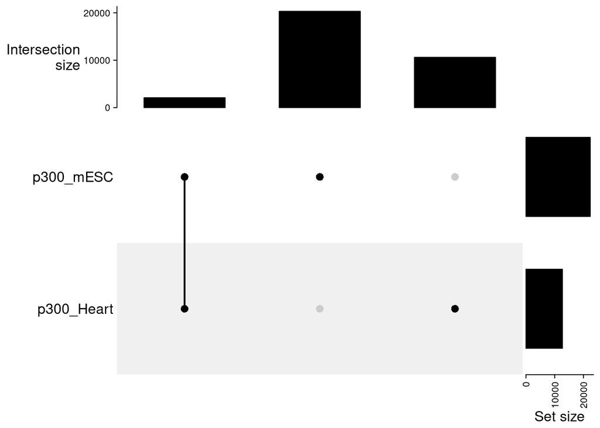

```r
overlaps_and_upset(peaks[grepl("p300", names(peaks))], FALSE)
```

Across all three targets, the unique peaks per tissue outnumber the interectin ones. This effect is largest in p300 and H3K27me3.